# Estimate nu via Kurtosis

### Compare estimation performance with $\nu$ changes

```r
N <- 10
T <- 15
nu_pool <- 3:20
res <- list()
for (i in 1:length(nu_pool)) {
  nu <- nu_pool[i]
  # print(nu)
  res[[i]] <- sapply(1:repeate, function(idx) {est_nu_kurtosis(genX(N = N, T = T, nu = nu))})
}

sapply(res, median)
```

```
##  [1]  7.781355  9.047315 10.352436 11.589125 11.661241 12.397975 13.316649
##  [8] 13.782545 13.409361 13.681494 13.364720 12.730546 13.499547 14.586374
## [15] 13.988864 13.279168 13.813898 14.724751
```

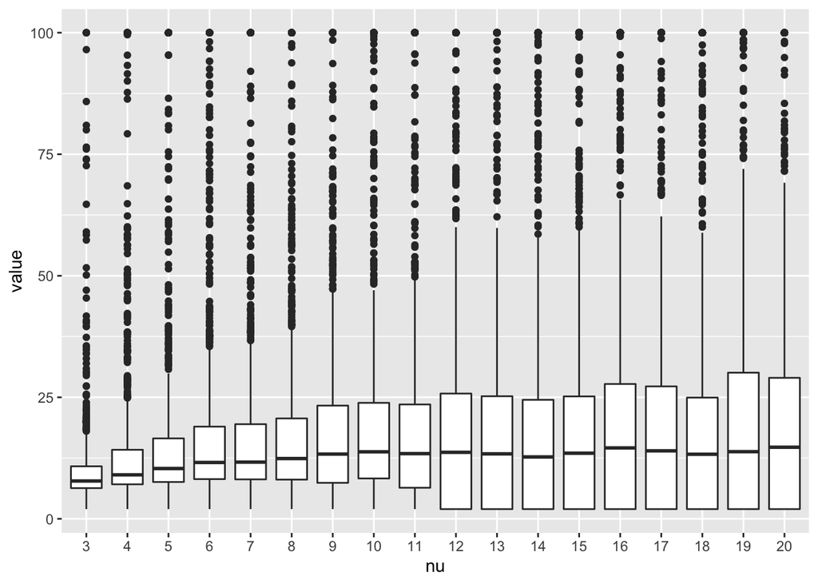

```r
library(ggplot2)
data <- reshape2::melt(data.frame("nu" = nu_pool, do.call(rbind, res)), id.vars = "nu")
data$nu <- as.factor(data$nu)
ggplot(data, aes(x = nu, y = value)) + geom_boxplot()
```

```r
# ggplot(data, aes(x = nu, y = value)) + geom_violin()
```

# Replace the mean of $\hat{\text{kurt}}$ by median value

### Compare estimation performance with $T$ changes

```r
N <- 10
res <- list()
for (i in 1:length(T_pool)) {
  T <- T_pool[i]
  # print(T)
  res[[i]] <- sapply(1:repeate, function(idx) {est_nu_kurtosis(genX(N = N, T = T), comb_fun = median)})
}

sapply(res, median)
```

```
##  [1]  8.952486  8.757263 10.639777 10.117412 10.378695 10.831389 11.294698
##  [8] 11.111472 11.838198 11.416271 11.469535
```

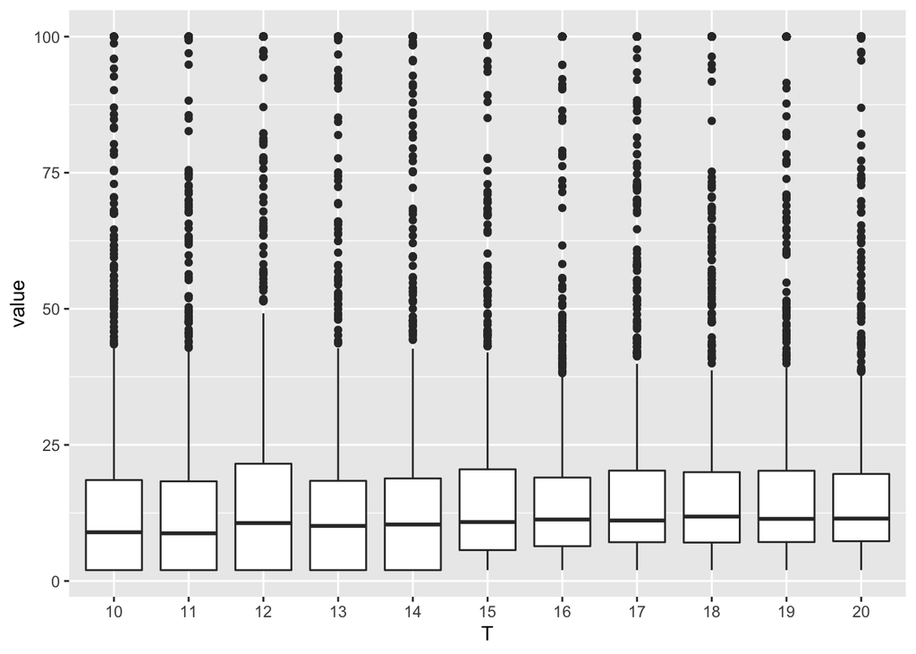

```r
library(ggplot2)
data <- reshape2::melt(data.frame("T" = T_pool, do.call(rbind, res)), id.vars = "T")
data$T <- as.factor(data$T)
ggplot(data, aes(x = T, y = value)) + geom_boxplot()
```

```r
# ggplot(data, aes(x = T, y = value)) + geom_violin()
```

### Compare estimation performance with $\nu$ changes

```r
N <- 10
T <- 15
res <- list()
for (i in 1:length(nu_pool)) {
  nu <- nu_pool[i]
  # print(nu)
  res[[i]] <- sapply(1:repeate, function(idx) {est_nu_kurtosis(genX(N = N, T = T, nu = nu), comb_fun = median)})
}

sapply(res, median)
```

```
##  [1]  8.957966 10.490204 10.820397 10.918088 11.689944 10.334305  9.370355
##  [8]  3.917835  2.000000  2.000000  2.000000  2.000000  2.000000  2.000000
## [15]  2.000000  2.000000  2.000000  2.000000
```

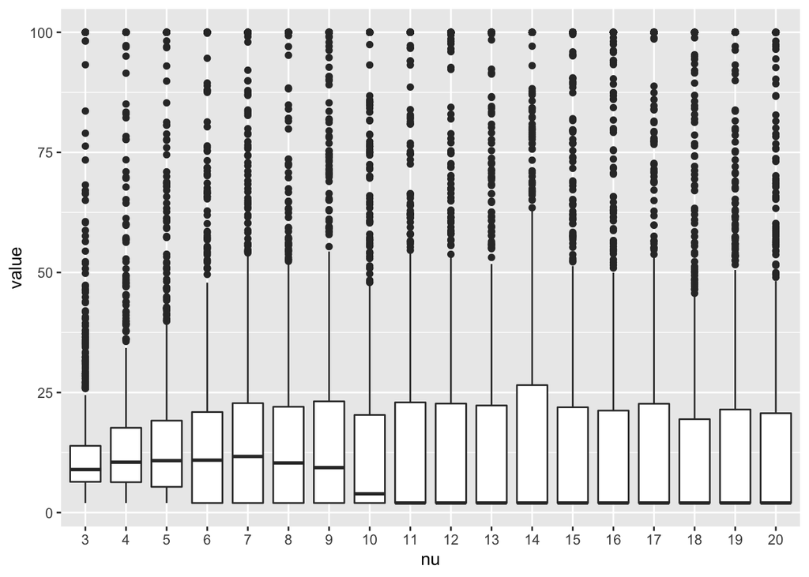

```r
library(ggplot2)
data <- reshape2::melt(data.frame("nu" = nu_pool, do.call(rbind, res)), id.vars = "nu")
data$nu <- as.factor(data$nu)
ggplot(data, aes(x = nu, y = value)) + geom_boxplot()
```

```r
# ggplot(data, aes(x = nu, y = value)) + geom_violin()
```

Well, it seems that using median value is worse than using the simple mean value.

# Try with large $N$

```r
N <- 100
T_pool <- seq(10, 200, 10)
res <- list()
for (i in 1:length(T_pool)) {
  T <- T_pool[i]
  # print(T)
  res[[i]] <- sapply(1:repeate, function(idx) {est_nu_kurtosis(genX(N = N, T = T))})
}

sapply(res, median)
```

```
##  [1] 14.225741 10.062568  8.736718  8.087211  7.650539  7.359973  7.211512
##  [8]  7.029086  6.936229  6.768492  6.757991  6.674580  6.525076  6.457001
## [15]  6.512512  6.441790  6.392957  6.269170  6.243431  6.257378
```

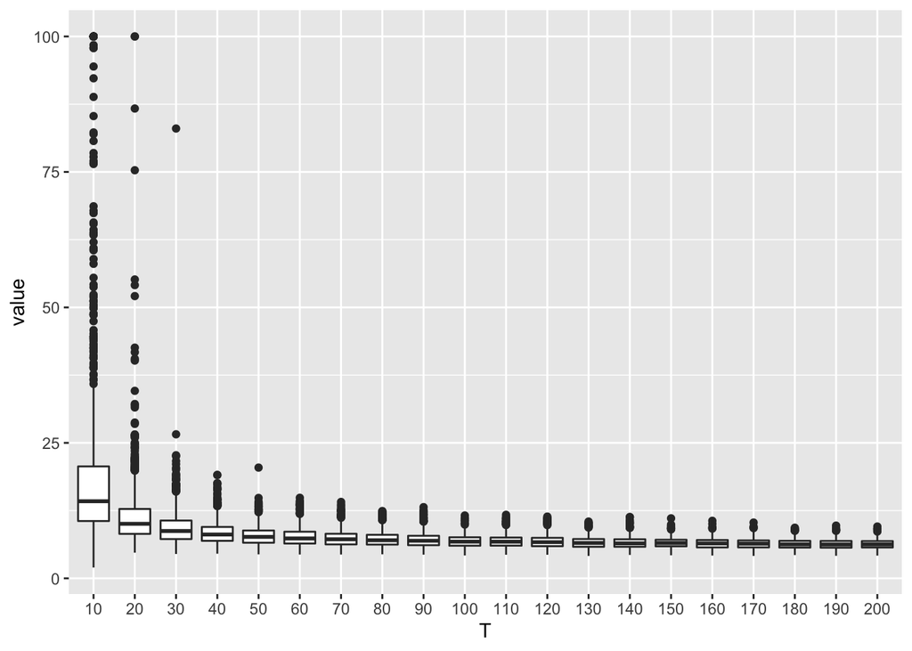

```r
library(ggplot2)
data <- reshape2::melt(data.frame("T" = T_pool, do.call(rbind, res)), id.vars = "T")
data$T <- as.factor(data$T)
ggplot(data, aes(x = T, y = value)) + geom_boxplot()
```

```r
# ggplot(data, aes(x = T, y = value)) + geom_violin()
```

It seems with large $N$, the etimators via kurtosis becomes really good.

# Compare estimation performance with $N$ changes

Now we fix the ratio $T/N$ be $1.1$ and change $N$ from $10$ to $100$ to see the results

```r
N_pool <- seq(10, 100, 10)
res <- list()
for (i in 1:length(N_pool)) {
  N <- N_pool[i]
  # print(T)
  res[[i]] <- sapply(1:repeate, function(idx) {est_nu_kurtosis(genX(N = N, T = round(N*1.1)))})
}

sapply(res, median)
```

```
##  [1] 10.574135  9.649608  8.517589  7.964832  7.474480  7.405642  7.078309
##  [8]  6.932454  6.742293  6.641360
```

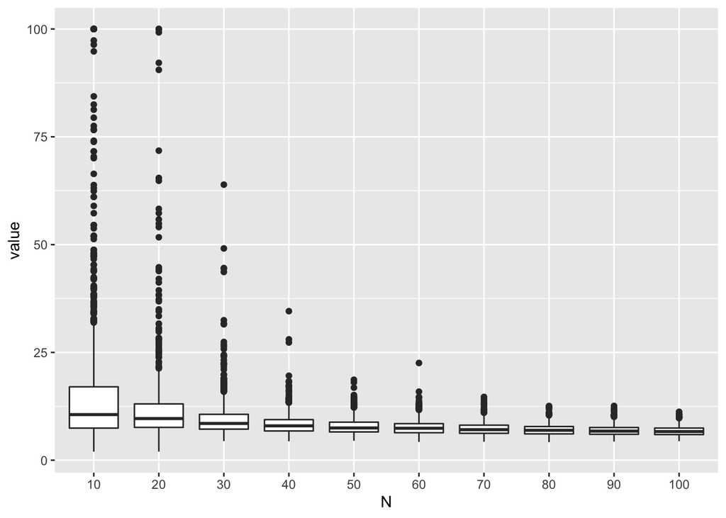

```r
library(ggplot2)
data <- reshape2::melt(data.frame("N" = N_pool, do.call(rbind, res)), id.vars = "N")
data$N <- as.factor(data$N)
ggplot(data, aes(x = N, y = value)) + geom_boxplot()
```

```r
# ggplot(data, aes(x = T, y = value)) + geom_violin()
```

It is clear that when $N$ increase, the estimation performance also improves. An explanation for that could be: the simple average of $\hat{\text{kurt}}$ become more reliable when $N$ goes large.

# Try with large $N \times T$

What if we keeps the $N \times T$ the same but change the $N$ and $T$ accordingly.

```r
allocate_NnT <- function(NxT, TN_ratios = c((1:9)/10, 1:10, NxT-1)) {
  N <- sqrt(NxT/TN_ratios)
  T <- N * TN_ratios;
  return(data.frame(N = round(N), T = round(T)))
}

# sanity check
tmp <- allocate_NnT(500)
str(tmp)
```

```
## 'data.frame':    20 obs. of  2 variables:
##  $ N: num  71 50 41 35 32 29 27 25 24 22 ...
##  $ T: num  7 10 12 14 16 17 19 20 21 22 ...
```

```r
tmp$N * tmp$T
```

```
##  [1] 497 500 492 490 512 493 513 500 504 484 512 507 495 500 495 472 504
## [18] 469 497 499
```

```r
NxT <- 200
TN_ratios = c((1:9)/10, 1:10, NxT-1)
NT_comb <- allocate_NnT(NxT = NxT, TN_ratios = TN_ratios)
res <- list()
for (i in 1:nrow(NT_comb)) {
  N <- NT_comb$N[i]
  T <- NT_comb$T[i]
  # print(T)
  # message("T = ", T, "\t N = ", N, "\t T x N = ", T*N)
  res[[i]] <- sapply(1:repeate, function(idx) {est_nu_kurtosis(genX(N = N, T = T))})
}
sapply(res, median)
```

```
##  [1] 14.808270 14.522176 13.603003 13.288691 12.448082 11.831428 11.533733
##  [8] 11.137378 11.179779 10.774514  9.980779  9.417050  8.963530  8.454413
## [15]  8.512751  8.439790  8.133286  8.350426  8.030714  7.182327
```

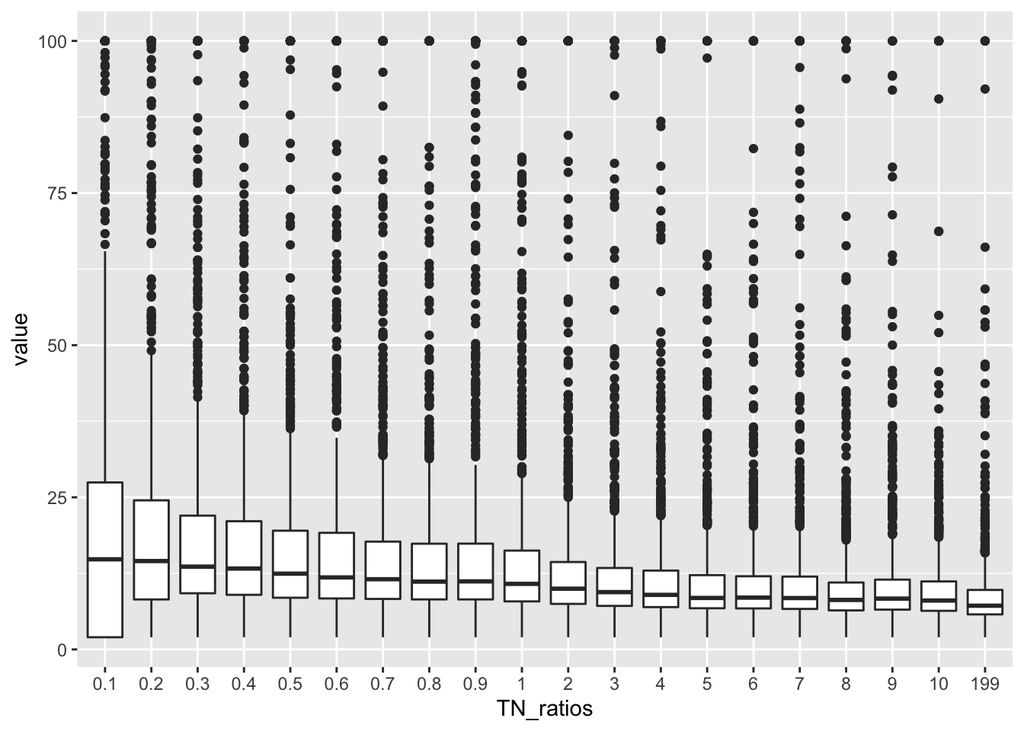

```r
library(ggplot2)
data <- reshape2::melt(data.frame("TN_ratios" = TN_ratios, do.call(rbind, res)), id.vars = "TN_ratios")
data$TN_ratios <- as.factor(data$TN_ratios)
ggplot(data, aes(x = TN_ratios, y = value)) + geom_boxplot()
```

```r
# ggplot(data, aes(x = T, y = value)) + geom_violin()
```

```r
NxT <- 500
NT_comb <- allocate_NnT(NxT = NxT, TN_ratios = TN_ratios)
res <- list()
for (i in 1:nrow(NT_comb)) {
  N <- NT_comb$N[i]
  T <- NT_comb$T[i]
  # print(T)
  # message("T = ", T, "\t N = ", N, "\t T x N = ", T*N)
  res[[i]] <- sapply(1:repeate, function(idx) {est_nu_kurtosis(genX(N = N, T = T))})
}

sapply(res, median)
```

```
##  [1] 17.077061 14.461010 12.877595 11.745630 11.355819 10.582944 10.246052
##  [8] 10.114388 10.212931  9.836693  8.680581  8.305167  7.829213  7.808412
## [15]  7.806593  7.545905  7.358468  7.402199  7.293243  6.340109
```

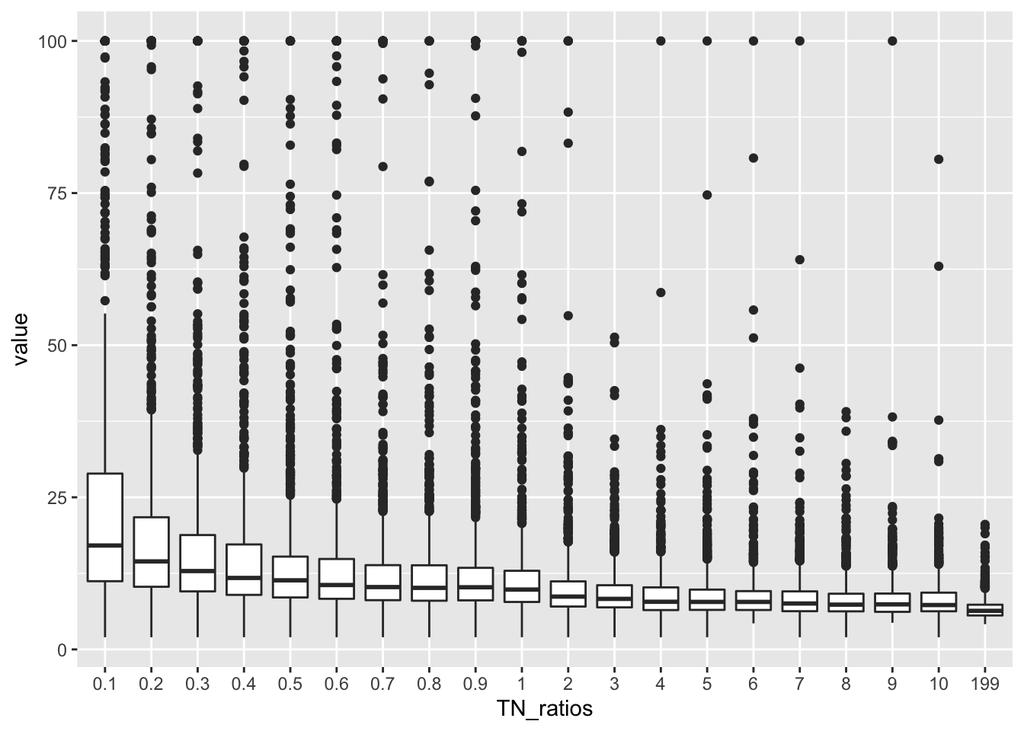

```r
library(ggplot2)
data <- reshape2::melt(data.frame("TN_ratios" = TN_ratios, do.call(rbind, res)), id.vars = "TN_ratios")
data$TN_ratios <- as.factor(data$TN_ratios)
ggplot(data, aes(x = TN_ratios, y = value)) + geom_boxplot()
```

```r
# ggplot(data, aes(x = T, y = value)) + geom_violin()
```

```r
NxT <- 1000
NT_comb <- allocate_NnT(NxT = NxT, TN_ratios = TN_ratios)
res <- list()
for (i in 1:nrow(NT_comb)) {
  N <- NT_comb$N[i]
  T <- NT_comb$T[i]
  # print(T)
  # message("T = ", T, "\t N = ", N, "\t T x N = ", T*N)
  res[[i]] <- sapply(1:repeate, function(idx) {est_nu_kurtosis(genX(N = N, T = T))})
}

sapply(res, median)
```

```
##  [1] 15.085916 12.148725 11.274971 10.110503  9.699232  9.678783  9.210653
##  [8]  9.011475  8.790964  8.846113  8.001206  7.562892  7.374358  7.247981
## [15]  7.107298  7.139872  6.906772  6.926452  6.877293  6.248915
```

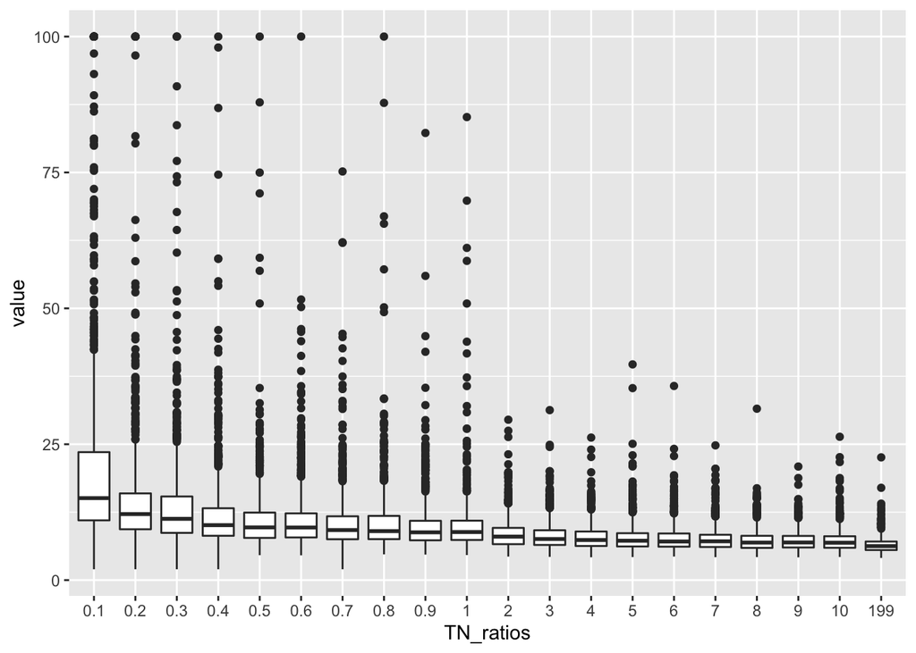

```r
library(ggplot2)
data <- reshape2::melt(data.frame("TN_ratios" = TN_ratios, do.call(rbind, res)), id.vars = "TN_ratios")
data$TN_ratios <- as.factor(data$TN_ratios)
ggplot(data, aes(x = TN_ratios, y = value)) + geom_boxplot()
```

```r
# ggplot(data, aes(x = T, y = value)) + geom_violin()
```

```r
NxT <- 1500
NT_comb <- allocate_NnT(NxT = NxT, TN_ratios = TN_ratios)
res <- list()
for (i in 1:nrow(NT_comb)) {
  N <- NT_comb$N[i]
  T <- NT_comb$T[i]
  # print(T)
  # message("T = ", T, "\t N = ", N, "\t T x N = ", T*N)
  res[[i]] <- sapply(1:repeate, function(idx) {est_nu_kurtosis(genX(N = N, T = T))})
}

sapply(res, median)
```

```
##  [1] 13.304965 10.758918  9.997657  9.583069  9.091380  8.669421  8.727158
##  [8]  8.439022  8.323711  8.172101  7.561580  7.402713  7.133997  7.003702
## [15]  6.898951  6.922944  6.885746  6.727010  6.635807  6.030951
```

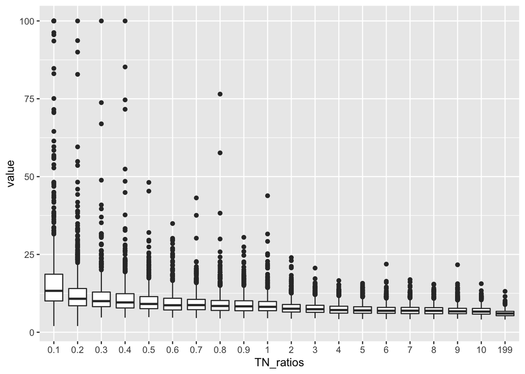

```r
library(ggplot2)
data <- reshape2::melt(data.frame("TN_ratios" = TN_ratios, do.call(rbind, res)), id.vars = "TN_ratios")
data$TN_ratios <- as.factor(data$TN_ratios)
ggplot(data, aes(x = TN_ratios, y = value)) + geom_boxplot()
```

```r
# ggplot(data, aes(x = T, y = value)) + geom_violin()
```

Seems $T$ is very essential for the accuracy of estimation.

# Try with $N$ change

```r
T <- 10
N_pool <- seq(1, 10, 1)
res <- list()
for (i in 1:length(N_pool)) {
  N <- N_pool[i]
  # print(T)
  res[[i]] <- sapply(1:repeate, function(idx) {est_nu_kurtosis(genX(N = N, T = T), comb_fun = median)})
}
sapply(res, median)
```

```
##  [1]  5.443303  7.015249  6.722606  7.536697  7.224114  8.132878  7.868751
##  [8]  9.151883  8.693063 10.356398
```

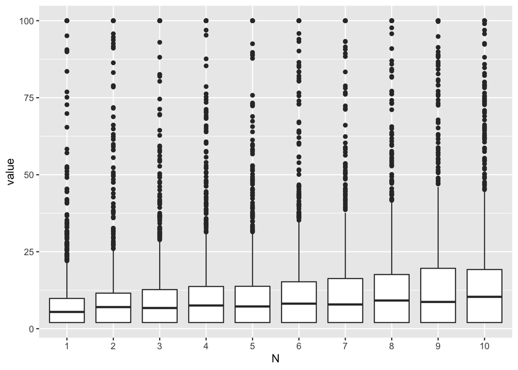

```r
library(ggplot2)
data <- reshape2::melt(data.frame("N" = N_pool, do.call(rbind, res)), id.vars = "N")
data$N <- as.factor(data$N)
ggplot(data, aes(x = N, y = value)) + geom_boxplot()
```

```r
# ggplot(data, aes(x = T, y = value)) + geom_violin()
```

```r
T <- 30
N_pool <- seq(1, 10, 1)
res <- list()
for (i in 1:length(N_pool)) {
  N <- N_pool[i]
  # print(T)
  res[[i]] <- sapply(1:repeate, function(idx) {est_nu_kurtosis(genX(N = N, T = T), comb_fun = median)})
}

sapply(res, median)
```

```
##  [1]  6.885903  7.794216  8.379954  9.736122  9.740696 10.265189 10.728229
##  [8] 10.524192 11.115928 11.148389
```

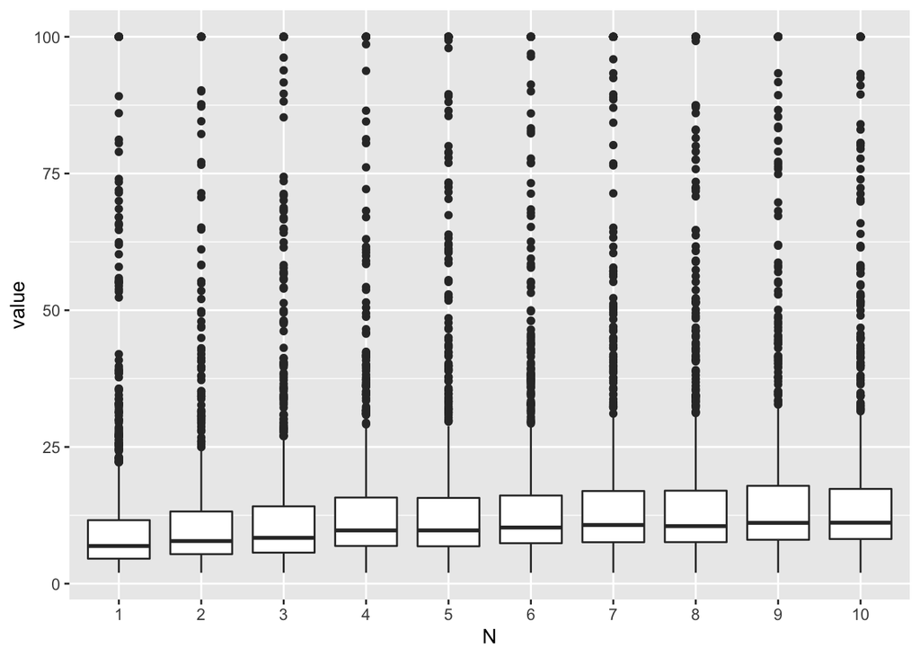

```r
library(ggplot2)
data <- reshape2::melt(data.frame("N" = N_pool, do.call(rbind, res)), id.vars = "N")
data$N <- as.factor(data$N)
ggplot(data, aes(x = N, y = value)) + geom_boxplot()
```

```r
# ggplot(data, aes(x = T, y = value)) + geom_violin()
```

```r
T <- 100
N_pool <- seq(1, 10, 1)
res <- list()
for (i in 1:length(N_pool)) {
  N <- N_pool[i]
  # print(T)
  res[[i]] <- sapply(1:repeate, function(idx) {est_nu_kurtosis(genX(N = N, T = T), comb_fun = median)})
}

sapply(res, median)
```

```
##  [1] 7.209574 7.337788 8.035330 7.710822 7.999922 7.929949 7.884799
##  [8] 7.948767 7.953017 7.982612
```

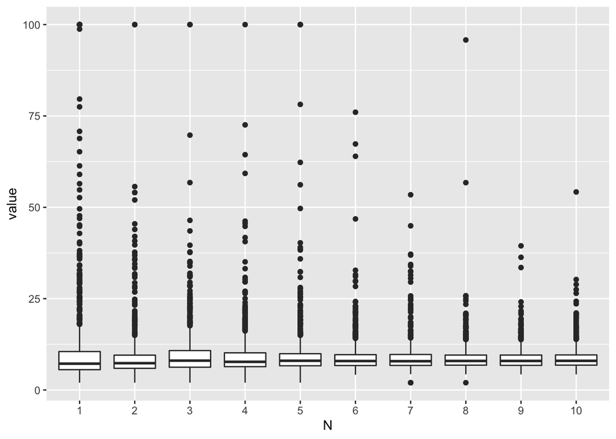

```r
library(ggplot2)
data <- reshape2::melt(data.frame("N" = N_pool, do.call(rbind, res)), id.vars = "N")
data$N <- as.factor(data$N)
ggplot(data, aes(x = N, y = value)) + geom_boxplot()
```

```r
# ggplot(data, aes(x = T, y = value)) + geom_violin()
```

```r
T <- 200
N_pool <- seq(1, 10, 1)
res <- list()
for (i in 1:length(N_pool)) {
  N <- N_pool[i]
  # print(T)
  res[[i]] <- sapply(1:repeate, function(idx) {est_nu_kurtosis(genX(N = N, T = T), comb_fun = median)})
}
sapply(res, median)
```

```
##  [1] 6.994920 6.720900 7.136281 7.026841 7.034623 7.061743 6.936963
##  [8] 6.968064 6.993816 7.054420
```

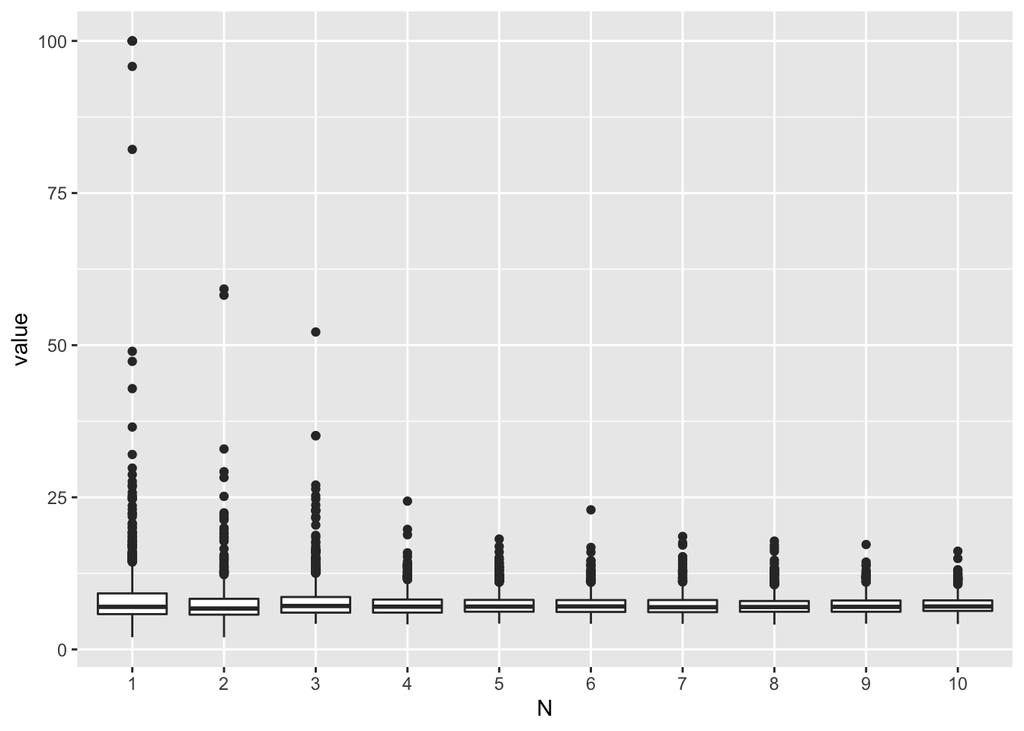

```r
library(ggplot2)
data <- reshape2::melt(data.frame("N" = N_pool, do.call(rbind, res)), id.vars = "N")
data$N <- as.factor(data$N)
ggplot(data, aes(x = N, y = value)) + geom_boxplot()
```

```r
# ggplot(data, aes(x = T, y = value)) + geom_violin()
```

Now the result becomes clear: $T$ is essential for such estimation. $N$ seems not to be that important.

It is not the $T/N$ ratio or $T \times N$. Only $T$ matters, then the bigger $N$ the better.